# Bruker to NIFTI BIDS format

BrkRaw

Diego Angeles-Valdez

2020-10-05

# Introducción

## Brkraw

El “BrkRaw” es un módulo de Python diseñado para acceder a los datos brutos adquiridos Bruker MRI scanner.

Authors:

- SungHo Lee (University of North Carolina)
- Woomi Ban (University of North Carolina)

## Instalación

Requerimientos Python 3.6, 3.7

https://brkraw.github.io/ – Vía Python

https://brkraw.github.io/docs/gs_inst.html — Vía Github

# BrkRaw en practica

### Activar brkraw local, ir al enviorment de Python

- Activar la version de Python `conda activate py37`

NOTA: Yo recomiendo Python3.7

### Activar brkraw en el cluster C13

- Para utilizar python `inb_anaconda_on`
- para utilizar brkraw `conda activate brkraw`

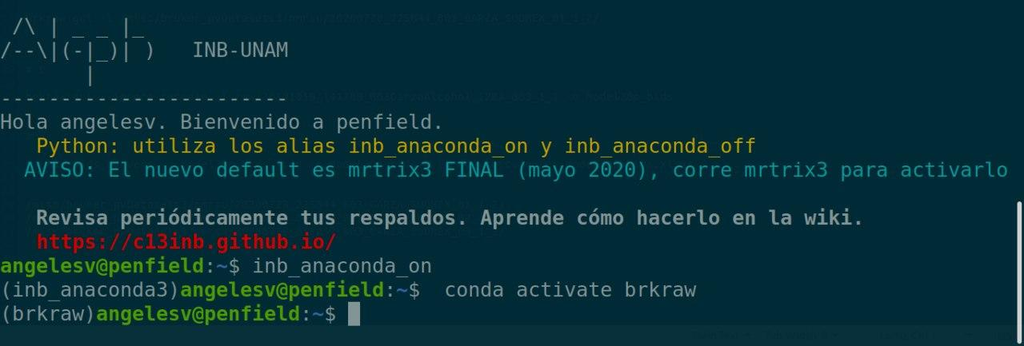

Cluster C13 - Activar Python & brkraw

# Example

## Data

Descargar data para el ejemplo, es necesario acceder al cluster C13

- /misc/bruker_pvDatasets3/nmrsu/20200728_225044_B03_GARZA_SUDMEX_01_1_2/
- /misc/bruker_pvDatasets3/nmrsu/20200729_000659_B03_GARZA_SUDMEX_02_1_2/
- /misc/bruker_pvDatasets3/nmrsu/20200729_012457_B03_GARZA_SUDMEX_03_1_2/

Agragar las carpetas a una carpeta principal **raw** (donde estarán las carpetas bruker) y una carpeta de output **Modelo**

El “BrkRaw” es un módulo de Python diseñado para acceder a los datos brutos adquiridos Bruker MRI scanner.

# Visualización

Comando:

`brkwaw gui -i # PATH de la carpeta de los archivos Bruker`

Example:

`brkraw gui -i /misc/bruker_pvDatasets3/nmrsu/20200728_225044_B03_GARZA_SUDMEX_01_1_2/`

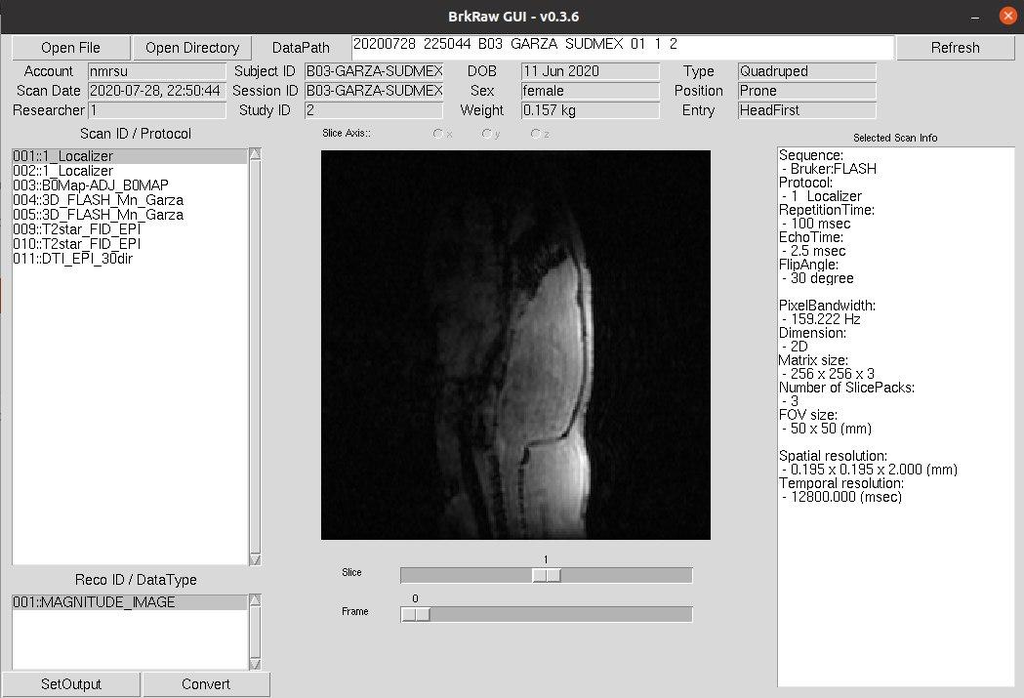

BrkRaw View

#### Revisar los datos

Añadir la opción de **–ignore-rescale** y exportar archivos.

Comando:

`brkraw gui --ignore-rescale -i {Folder_input} -o {Folder_ouput}`

Example:

`brkraw gui --ignore-rescale -i raw/20191018_141708_B03GarzaAlcohol_I2BA_003_1_1 -o Modelo`

## Formato BIDS

El formato BIDS es un formato de organización de datos de MRI, para mayores detalles, revisar.

https://bids.neuroimaging.io/

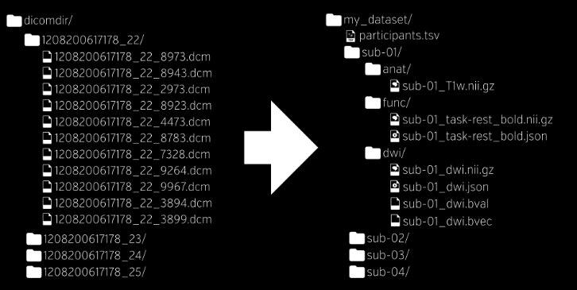

Estructura BIDS

#### Obtener json y archivos excel

Comando: `brkraw bids_helper -j {Folder_input} {Folder_output}` Nota: Añadir la opción -j (jason)

Example: `brkraw bids_helper -j raw Modelo`

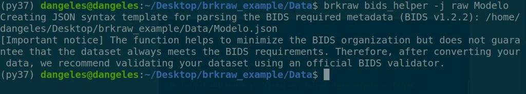

Revisar data

#### Editar el archivo **.xlsx**, editar las columnas (SubjID, SessID, task)

# Convertir a BIDS

`brkraw bids_convert -j Model20p_bids.json -o Model20p_bids --ignore-rescale raw Model20p_bids.xlsx`

# BIDS validation

Es importante revisar la estructura de los datos. Para ello utilizamos la herramienta BIDS Validator v1.5.4 https://bids-standard.github.io/bids-validator/

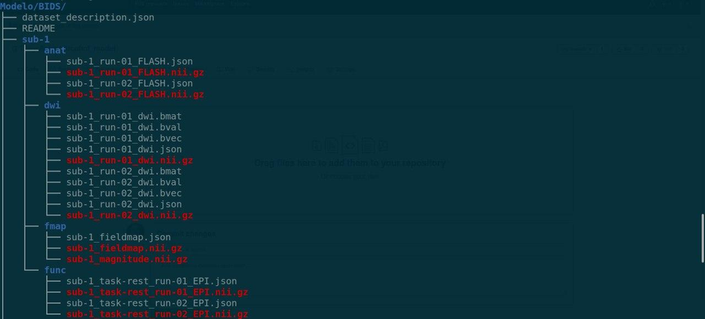

Revisar data